# Trump’s tweets

Duncan Golicher

February 2017

## Introduction

In August 2016 a data anayst made the news by proving that Donald Trump’s Twitter account was being used by at least two separate people. The story made the Washington post. http://varianceexplained.org/r/trump-tweets/

https://www.washingtonpost.com/posteverything/wp/2016/08/12/two-people-write-trumps-tweets-he-writes-the-angrier-ones/

Today, Donald Trump tweeted some complementary comments about women (on international women’s day). http://www.politico.com/story/2017/03/trump-womens-day-tweet-235814 The problem is that the nice comments all came from an IPhone. David Robinson’s analysis showed that Trump himself uses an Android device.

David Robinson has claimed that he is no longer analysing Trump’s tweets due to the adverse reaction he provoked. However no one is going to notice my reanalysis, so I pulled down his code, tweaked it a little, and re ran it to see if Trump and his team have swopped devices.

```r
library(readr)
trump_tweets_df<-read_csv("trump_tweets.csv")
```

## Taking recent tweets

```r
library(tidyr)

tweets <- trump_tweets_df %>%
  select(id, statusSource, text, created) %>%
  extract(statusSource, "source", "Twitter for (.*?)<") %>%
  filter(source %in% c("iPhone", "Android"))
```

## Time of day and device used

The key indicator that seemed to confirm that two devices were being used was the time of day on which the tweets were sent. Early in the day angry tweets were sent from an android device during the campaign. More measured tweets came from an Iphone later on. Is this still happening?

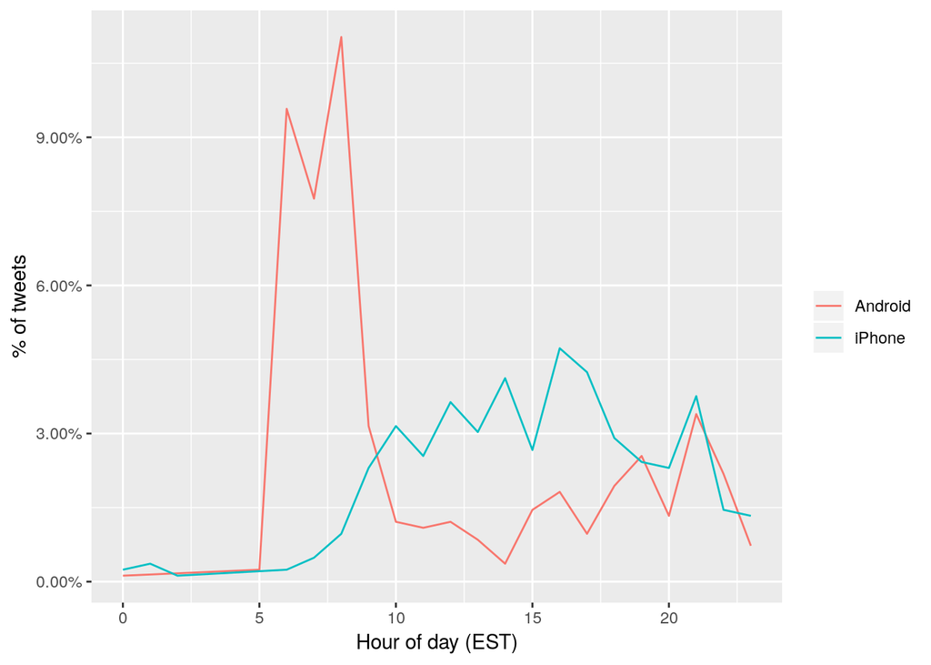

```r
library(lubridate)
library(scales)

tweets %>%
  count(source, hour = hour(with_tz(created, "EST"))) %>%
  mutate(percent = n / sum(n)) %>%
  ggplot(aes(hour, percent, color = source)) +
  geom_line() +
  scale_y_continuous(labels = percent_format()) +
  labs(x = "Hour of day (EST)",
       y = "% of tweets",
       color = "")
```

It certainly appears so!

```r
library(tidytext)

reg <- "([^A-Za-z\\d#@']|'(?![A-Za-z\\d#@]))"
tweet_words <- tweets %>%
  filter(!str_detect(text, '^"')) %>%
  mutate(text = str_replace_all(text, "https://t.co/[A-Za-z\\d]+|&amp;", "")) %>%
  unnest_tokens(word, text, token = "regex", pattern = reg) %>%
  filter(!word %in% stop_words$word,
         str_detect(word, "[a-z]"))
```

## Most common words

It is interesting to look at the raw vocabulary being used.

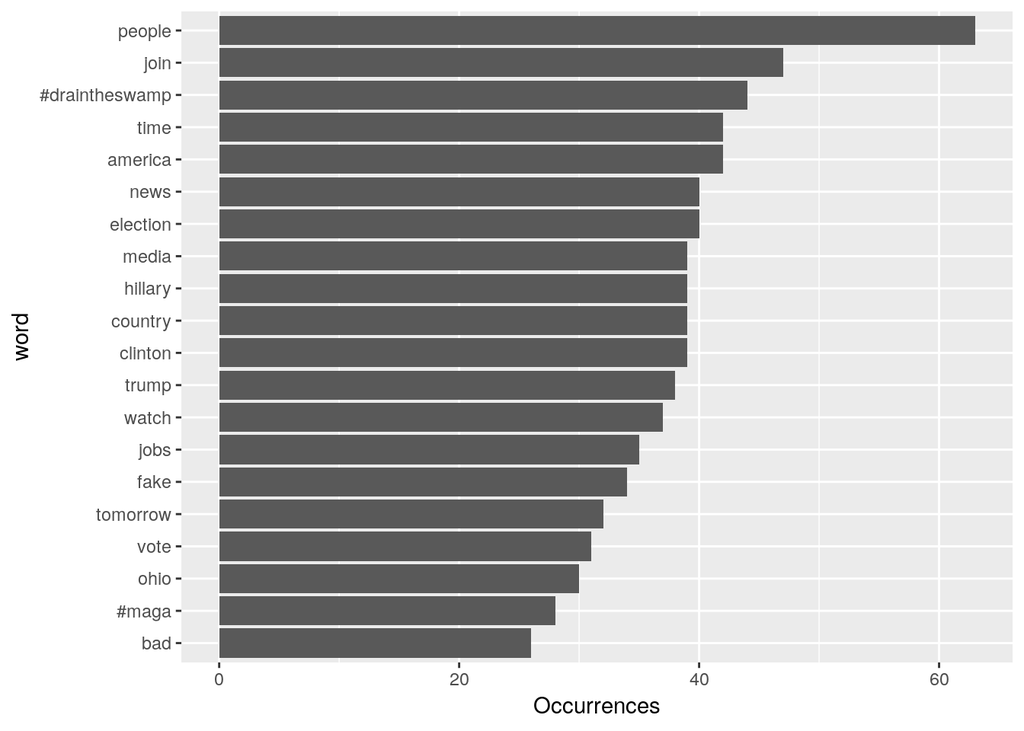

```r
tweet_words %>%
  count(word, sort = TRUE) %>%
  head(20) %>%
  mutate(word = reorder(word, n)) %>%
  ggplot(aes(word, n)) +
  geom_bar(stat = "identity") +
  ylab("Occurrences") +
  coord_flip()
```

Donald Trump’s android device is used to rant about the press.

## Splitting occurences by device

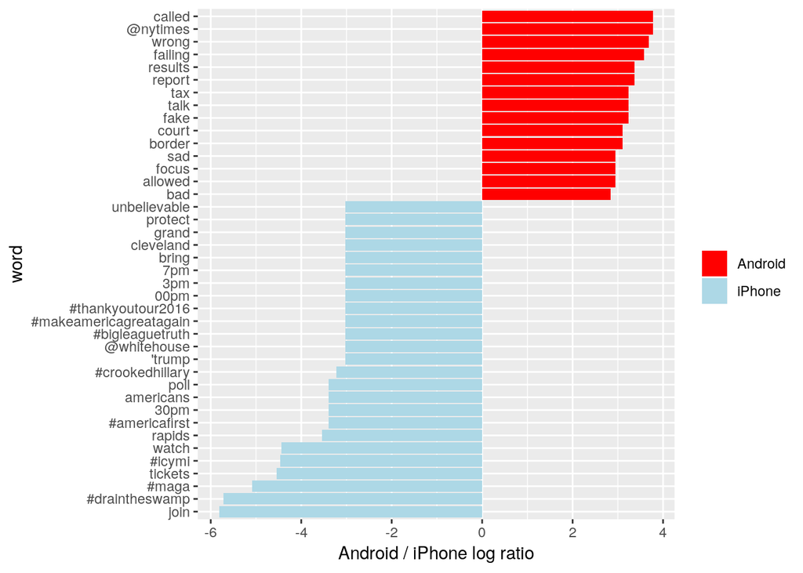

```r
android_iphone_ratios <- tweet_words %>%
  count(word, source) %>%
  filter(sum(n) >= 5) %>%
  spread(source, n, fill = 0) %>%
  ungroup() %>%
  mutate_each(funs((. + 1) / sum(. + 1)), -word) %>%
  mutate(logratio = log2(Android / iPhone)) %>%
  arrange(desc(logratio))

android_iphone_ratios %>%
  group_by(logratio > 0) %>%
  top_n(15, abs(logratio)) %>%
  ungroup() %>%
  mutate(word = reorder(word, logratio)) %>%
  ggplot(aes(word, logratio, fill = logratio < 0)) +
  geom_bar(stat = "identity") +
  coord_flip() +
  ylab("Android / iPhone log ratio") +
  scale_fill_manual(name = "", labels = c("Android", "iPhone"),
                    values = c("red", "lightblue"))
```

## Sentiment analysis

What sort of sentiments are used in the tweets and is there any relationship between the sentiment and the device of origin?

```r
nrc <- sentiments %>%
  filter(lexicon == "nrc") %>%
  dplyr::select(word, sentiment)
```

```r
sources <- tweet_words %>%
  group_by(source) %>%
  mutate(total_words = n()) %>%
  ungroup() %>%
  distinct(id, source, total_words)

by_source_sentiment <- tweet_words %>%
  inner_join(nrc, by = "word") %>%
  count(sentiment, id) %>%
  ungroup() %>%
  complete(sentiment, id, fill = list(n = 0)) %>%
  inner_join(sources) %>%
  group_by(source, sentiment, total_words) %>%
  summarize(words = sum(n)) %>%
  arrange(-words) %>%
  ungroup()

dd<-head(by_source_sentiment,30)
dd
```

```
## # A tibble: 20 x 4
##    source  sentiment    total_words words
##    <chr>   <chr>              <int> <dbl>
##  1 Android positive            3538   447
##  2 Android negative            3538   414
##  3 iPhone  positive            2700   317
##  4 Android trust               3538   291
##  5 Android anticipation        3538   234
##  6 Android fear                3538   232
##  7 Android sadness             3538   231
##  8 Android anger               3538   228
##  9 iPhone  trust               2700   225
## 10 iPhone  anticipation        2700   192
## 11 Android joy                 3538   174
## 12 Android disgust             3538   167
## 13 iPhone  negative            2700   165
## 14 iPhone  joy                 2700   131
## 15 iPhone  fear                2700   119
## 16 Android surprise            3538   111
## 17 iPhone  anger               2700    88
## 18 iPhone  surprise            2700    86
## 19 iPhone  sadness             2700    78
## 20 iPhone  disgust             2700    54
```

## Analysis using log odds ratio

```r
library(broom)

sentiment_differences <- by_source_sentiment %>%
  group_by(sentiment) %>%
  do(tidy(poisson.test(.$words, .$total_words)))
```

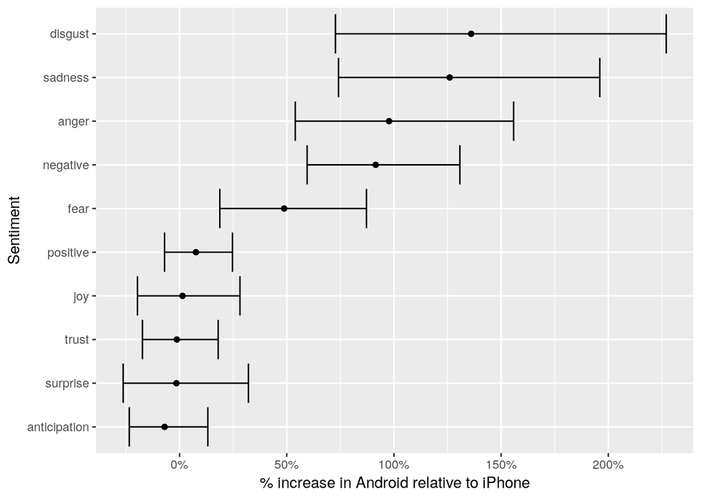

```r
library(scales)

sentiment_differences %>%
  ungroup() %>%
  mutate(sentiment = reorder(sentiment, estimate)) %>%
  mutate_each(funs(. - 1), estimate, conf.low, conf.high) %>%
  ggplot(aes(estimate, sentiment)) +
  geom_point() +
  geom_errorbarh(aes(xmin = conf.low, xmax = conf.high)) +
  scale_x_continuous(labels = percent_format()) +
  labs(x = "% increase in Android relative to iPhone",
       y = "Sentiment")
```

## Which words are associated with the emotions?

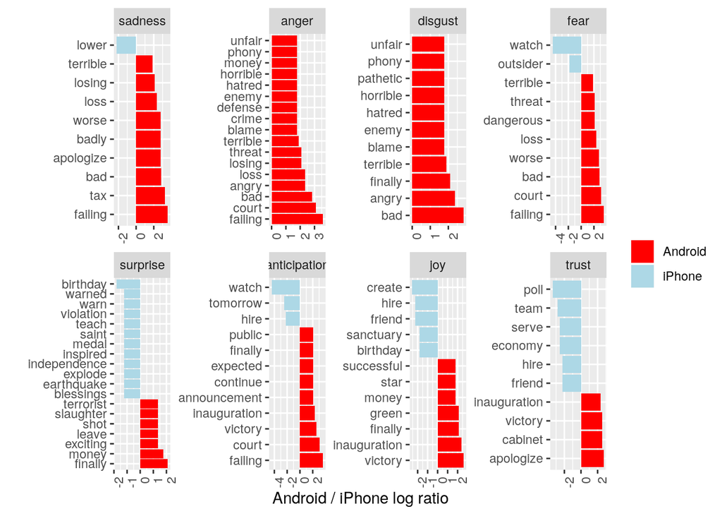

```r
android_iphone_ratios %>%
  inner_join(nrc, by = "word") %>%
  filter(!sentiment %in% c("positive", "negative")) %>%
  mutate(sentiment = reorder(sentiment, -logratio),
         word = reorder(word, -logratio)) %>%
  group_by(sentiment) %>%
  top_n(10, abs(logratio)) %>%
  ungroup() %>%
  ggplot(aes(word, logratio, fill = logratio < 0)) +
  facet_wrap(~ sentiment, scales = "free", nrow = 2) +
  geom_bar(stat = "identity") +
  theme(axis.text.x = element_text(angle = 90, hjust = 1)) +
  labs(x = "", y = "Android / iPhone log ratio") + coord_flip()+
  scale_fill_manual(name = "", labels = c("Android", "iPhone"),
                    values = c("red", "lightblue"))
```

## Word cloud for Android

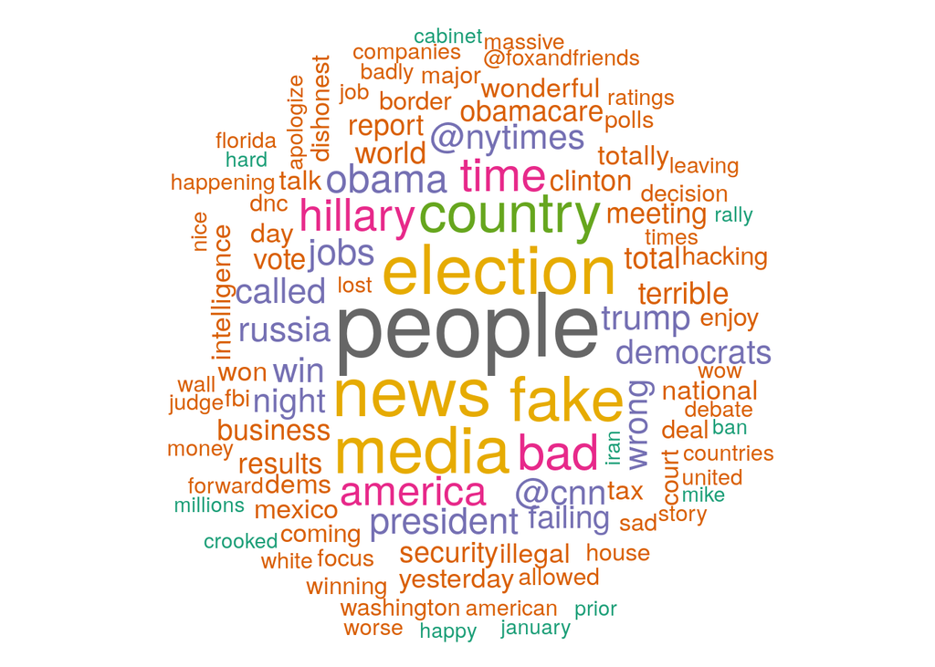

```r
tweet_words %>%
  group_by(word,source) %>%
  count() ->allwords

words<-subset(allwords,source=="Android")
wordcloud(words$word, words$n, random.order=FALSE, max.words = 100, colors=brewer.pal(8, "Dark2"), use.r.layout=TRUE)
```

## Word cloud for IPhone

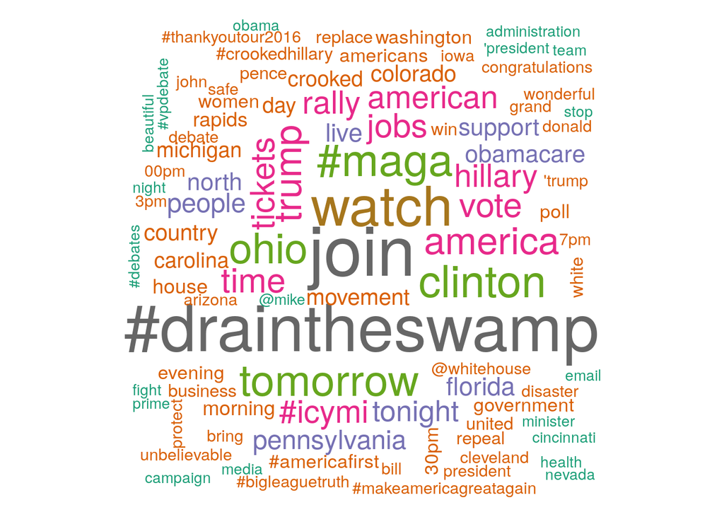

```r
words<-subset(allwords,source=="iPhone")
wordcloud(words$word, words$n, random.order=FALSE, max.words = 100, colors=brewer.pal(8, "Dark2"), use.r.layout=TRUE)
```

https://bitbucket.org/dgolicher/aqm2017/raw/a0a96bdb972804b78011944d2432e20a343434b6/TrumpTweets.Rmd